# DATA621 - Insurance

Daniel Hong, Mauricio Alarcon, Maxwell Wagner

October 10, 2016

## 1. DATA EXPLORATION (25 Points)

Describe the size and the variables in the insurance training data set. Consider that too much detail will cause a manager to lose interest while too little detail will make the manager consider that you arenât doing your job. Some suggestions are given below. Please do NOT treat this as a check list of things to do to complete the assignment. You should have your own thoughts on what to tell the boss. These are just ideas.

1. Mean / Standard Deviation / Median
2. Bar Chart or Box Plot of the data
3. Is the data correlated to the target variable (or to other variables?)
4. Are any of the variables missing and need to be imputed âfixedâ?
1. Mean / Standard Deviation / Median

```r
require("plyr")
require("knitr")
require("psych")
# Let's load the data

training <- read.csv(url('https://raw.githubusercontent.com/rmalarc/DATA621/master/hw04/insurance_training_data.csv'),stringsAsFactors = FALSE)
metadata <- read.csv(url('https://raw.githubusercontent.com/rmalarc/DATA621/master/hw04/insurance-metadata.csv'))
colnames(metadata) <- c("Variable", "Name Definition", "Theoretical Effect")
evaluation <- read.csv(url('https://raw.githubusercontent.com/rmalarc/DATA621/master/hw04/insurance-evaluation-data.csv'),stringsAsFactors = FALSE)

kable(metadata)
```

| Variable | Name Definition | Theoretical Effect |
| --- | --- | --- |
| INDEX | Identification Variable (do not use) | None |
| TARGET_FLAG | Was Car in a crash? 1=YES 0=NO | None |
| TARGET_AMT | If car was in a crash, what was the cost | None |
| AGE | Age of Driver | Very young people tend to be risky. Maybe very old people also. |
| BLUEBOOK | Value of Vehicle | Unknown effect on probability of collision, but probably effect the payout if there is a crash |
| CAR_AGE | Vehicle Age | Unknown effect on probability of collision, but probably effect the payout if there is a crash |
| CAR_TYPE | Type of Car | Unknown effect on probability of collision, but probably effect the payout if there is a crash |
| CAR_USE | Vehicle Use | Commercial vehicles are driven more, so might increase probability of collision |
| CLM_FREQ | # Claims (Past 5 Years) | The more claims you filed in the past, the more you are likely to file in the future |
| EDUCATION | Max Education Level | Unknown effect, but in theory more educated people tend to drive more safely |
| HOMEKIDS | # Children at Home | Unknown effect |
| HOME_VAL | Home Value | In theory, home owners tend to drive more responsibly |
| INCOME | Income | In theory, rich people tend to get into fewer crashes |
| JOB | Job Category | In theory, white collar jobs tend to be safer |
| KIDSDRIV | # Driving Children | When teenagers drive your car, you are more likely to get into crashes |
| MSTATUS | Marital Status | In theory, married people drive more safely |
| MVR_PTS | Motor Vehicle Record Points | If you get lots of traffic tickets, you tend to get into more crashes |
| OLDCLAIM | Total Claims (Past 5 Years) | If your total payout over the past five years was high, this suggests future payouts will be high |
| PARENT1 | Single Parent | Unknown effect |
| RED_CAR | A Red Car | Urban legend says that red cars (especially red sports cars) are more risky. Is that true? |
| REVOKED | License Revoked (Past 7 Years) | If your license was revoked in the past 7 years, you probably are a more risky driver. |
| SEX | Gender | Urban legend says that women have less crashes then men. Is that true? |
| TIF | Time in Force | People who have been customers for a long time are usually more safe. |
| TRAVTIME | Distance to Work | Long drives to work usually suggest greater risk |
| URBANICITY | Home/Work Area | Unknown |
| YOJ | Years on Job | People who stay at a job for a long time are usually more safe |

```r
columns <- colnames(training)
target <- "TARGET_FLAG"
inputs <- columns[!columns %in% c(target,"INDEX")]


summary <- describe(training[,c(target,inputs)],na.rm = TRUE)[,c("n","mean","sd","median","min","max")]
summary$completeness <- summary$n/nrow(training)
summary$cv <- 100*summary$sd/summary$mean

kable(summary)
```

|  | n | mean | sd | median | min | max | completeness | cv |
| --- | --- | --- | --- | --- | --- | --- | --- | --- |
| TARGET_FLAG | 8161 | 0.2638157 | 0.4407276 | 0 | 0 | 1.0 | 1.0000000 | 167.05888 |
| TARGET_AMT | 8161 | 1504.3246481 | 4704.0269298 | 0 | 0 | 107586.1 | 1.0000000 | 312.70025 |
| KIDSDRIV | 8161 | 0.1710575 | 0.5115341 | 0 | 0 | 4.0 | 1.0000000 | 299.04224 |
| AGE | 8155 | 44.7903127 | 8.6275895 | 45 | 16 | 81.0 | 0.9992648 | 19.26218 |
| HOMEKIDS | 8161 | 0.7212351 | 1.1163233 | 0 | 0 | 5.0 | 1.0000000 | 154.77938 |
| YOJ | 7707 | 10.4992864 | 4.0924742 | 11 | 0 | 23.0 | 0.9443696 | 38.97859 |
| INCOME* | 8161 | NaN | NA | NA | Inf | -Inf | 1.0000000 | NA |
| PARENT1* | 8161 | NaN | NA | NA | Inf | -Inf | 1.0000000 | NA |
| HOME_VAL* | 8161 | NaN | NA | NA | Inf | -Inf | 1.0000000 | NA |
| MSTATUS* | 8161 | NaN | NA | NA | Inf | -Inf | 1.0000000 | NA |
| SEX* | 8161 | NaN | NA | NA | Inf | -Inf | 1.0000000 | NA |
| EDUCATION* | 8161 | NaN | NA | NA | Inf | -Inf | 1.0000000 | NA |
| JOB* | 8161 | NaN | NA | NA | Inf | -Inf | 1.0000000 | NA |
| TRAVTIME | 8161 | 33.4857248 | 15.9083334 | 33 | 5 | 142.0 | 1.0000000 | 47.50781 |
| CAR_USE* | 8161 | NaN | NA | NA | Inf | -Inf | 1.0000000 | NA |
| BLUEBOOK* | 8161 | NaN | NA | NA | Inf | -Inf | 1.0000000 | NA |
| TIF | 8161 | 5.3513050 | 4.1466353 | 4 | 1 | 25.0 | 1.0000000 | 77.48830 |
| CAR_TYPE* | 8161 | NaN | NA | NA | Inf | -Inf | 1.0000000 | NA |
| RED_CAR* | 8161 | NaN | NA | NA | Inf | -Inf | 1.0000000 | NA |
| OLDCLAIM* | 8161 | NaN | NA | NA | Inf | -Inf | 1.0000000 | NA |
| CLM_FREQ | 8161 | 0.7985541 | 1.1584527 | 0 | 0 | 5.0 | 1.0000000 | 145.06878 |
| REVOKED* | 8161 | NaN | NA | NA | Inf | -Inf | 1.0000000 | NA |
| MVR_PTS | 8161 | 1.6955030 | 2.1471117 | 1 | 0 | 13.0 | 1.0000000 | 126.63568 |
| CAR_AGE | 7651 | 8.3283231 | 5.7007424 | 8 | -3 | 28.0 | 0.9375077 | 68.45006 |
| URBANICITY* | 8161 | NaN | NA | NA | Inf | -Inf | 1.0000000 | NA |

```r
head(training)
```

```
##   INDEX TARGET_FLAG TARGET_AMT KIDSDRIV AGE HOMEKIDS YOJ   INCOME PARENT1
## 1     1           0          0        0  60        0  11  $67,349      No
## 2     2           0          0        0  43        0  11  $91,449      No
## 3     4           0          0        0  35        1  10  $16,039      No
## 4     5           0          0        0  51        0  14               No
## 5     6           0          0        0  50        0  NA $114,986      No
## 6     7           1       2946        0  34        1  12 $125,301     Yes
##   HOME_VAL MSTATUS SEX     EDUCATION           JOB TRAVTIME    CAR_USE
## 1       $0    z_No   M           PhD  Professional       14    Private
## 2 $257,252    z_No   M z_High School z_Blue Collar       22 Commercial
## 3 $124,191     Yes z_F z_High School      Clerical        5    Private
## 4 $306,251     Yes   M  <High School z_Blue Collar       32    Private
## 5 $243,925     Yes z_F           PhD        Doctor       36    Private
## 6       $0    z_No z_F     Bachelors z_Blue Collar       46 Commercial
##   BLUEBOOK TIF   CAR_TYPE RED_CAR OLDCLAIM CLM_FREQ REVOKED MVR_PTS
## 1  $14,230  11    Minivan     yes   $4,461        2      No       3
## 2  $14,940   1    Minivan     yes       $0        0      No       0
## 3   $4,010   4      z_SUV      no  $38,690        2      No       3
## 4  $15,440   7    Minivan     yes       $0        0      No       0
## 5  $18,000   1      z_SUV      no  $19,217        2     Yes       3
## 6  $17,430   1 Sports Car      no       $0        0      No       0
##   CAR_AGE          URBANICITY
## 1      18 Highly Urban/ Urban
## 2       1 Highly Urban/ Urban
## 3      10 Highly Urban/ Urban
## 4       6 Highly Urban/ Urban
## 5      17 Highly Urban/ Urban
## 6       7 Highly Urban/ Urban
```

```r
summary(training)
```

```
##      INDEX        TARGET_FLAG       TARGET_AMT        KIDSDRIV
##  Min.   :    1   Min.   :0.0000   Min.   :     0   Min.   :0.0000
##  1st Qu.: 2559   1st Qu.:0.0000   1st Qu.:     0   1st Qu.:0.0000
##  Median : 5133   Median :0.0000   Median :     0   Median :0.0000
##  Mean   : 5152   Mean   :0.2638   Mean   :  1504   Mean   :0.1711
##  3rd Qu.: 7745   3rd Qu.:1.0000   3rd Qu.:  1036   3rd Qu.:0.0000
##  Max.   :10302   Max.   :1.0000   Max.   :107586   Max.   :4.0000
##
##       AGE           HOMEKIDS           YOJ          INCOME
##  Min.   :16.00   Min.   :0.0000   Min.   : 0.0   Length:8161
##  1st Qu.:39.00   1st Qu.:0.0000   1st Qu.: 9.0   Class :character
##  Median :45.00   Median :0.0000   Median :11.0   Mode  :character
##  Mean   :44.79   Mean   :0.7212   Mean   :10.5
##  3rd Qu.:51.00   3rd Qu.:1.0000   3rd Qu.:13.0
##  Max.   :81.00   Max.   :5.0000   Max.   :23.0
##  NA's   :6                        NA's   :454
##    PARENT1            HOME_VAL           MSTATUS
##  Length:8161        Length:8161        Length:8161
##  Class :character   Class :character   Class :character
##  Mode  :character   Mode  :character   Mode  :character
##
##
##
##
##      SEX             EDUCATION             JOB               TRAVTIME
##  Length:8161        Length:8161        Length:8161        Min.   :  5.00
##  Class :character   Class :character   Class :character   1st Qu.: 22.00
##  Mode  :character   Mode  :character   Mode  :character   Median : 33.00
##                                                           Mean   : 33.49
##                                                           3rd Qu.: 44.00
##                                                           Max.   :142.00
##
##    CAR_USE            BLUEBOOK              TIF           CAR_TYPE
##  Length:8161        Length:8161        Min.   : 1.000   Length:8161
##  Class :character   Class :character   1st Qu.: 1.000   Class :character
##  Mode  :character   Mode  :character   Median : 4.000   Mode  :character
##                                        Mean   : 5.351
##                                        3rd Qu.: 7.000
##                                        Max.   :25.000
##
##    RED_CAR            OLDCLAIM            CLM_FREQ        REVOKED
##  Length:8161        Length:8161        Min.   :0.0000   Length:8161
##  Class :character   Class :character   1st Qu.:0.0000   Class :character
##  Mode  :character   Mode  :character   Median :0.0000   Mode  :character
##                                        Mean   :0.7986
##                                        3rd Qu.:2.0000
##                                        Max.   :5.0000
##
##     MVR_PTS          CAR_AGE        URBANICITY
##  Min.   : 0.000   Min.   :-3.000   Length:8161
##  1st Qu.: 0.000   1st Qu.: 1.000   Class :character
##  Median : 1.000   Median : 8.000   Mode  :character
##  Mean   : 1.696   Mean   : 8.328
##  3rd Qu.: 3.000   3rd Qu.:12.000
##  Max.   :13.000   Max.   :28.000
##                   NA's   :510
```

## 2. DATA PREPARATION (25 Points)

Describe how you have transformed the data by changing the original variables or creating new variables. If you did transform the data or create new variables, discuss why you did this. Here are some possible transformations.

1. Fix missing values (maybe with a Mean or Median value)
2. Create flags to suggest if a variable was missing
3. Transform data by putting it into buckets
4. Mathematical transforms such as log or square root (or use Box-Cox)
5. Combine variables (such as ratios or adding or multiplying) to create new variables

### Data Transformations

Based on the dataset description we need to:

- Convert INCOME to numeric, replace 0 for NA
- Convert PARENT1 to flag (1/0)
- Convert HOME_VAL to NON_HOMEOWNER flag
- Convert MSTATUS to Flag IS_SINGLE (1/0)
- Convert SEX to Flag (IS_MALE)
- Breakout EDUCATION into ED_HS, ED_BACHELORS,ED_MASTERS, ED_PHD
- Breakout JOB into JOB_BLUE_COLLAR, JOB_CLERICAL, JOB_PROFESSIONAL, JOB_MANAGERIAL, JOB_LAWYER, JOB_STUDENT,JOB_DOCTOR, JOB_HOME_MAKER
- Convert CAR_USE to flat(1/0 IS_COMMERCIAL)
- Convert BLUEBOOK to numeric
- Breakout CAR_TYPE into: CAR_PANEL_TRUCK,CAR_PICKUP,CAR_SPORTS_CAR,CAR_VAN,CAR_SUV
- Convert RED_CAR to flag (1/0)
- Convert OLDCLAIM to numeric
- Convert REVOKED to flag (1/0)
- Convert URBANICITY to flag (1/0 IS_URBAN)

```r
parseStringValue <- function(v, zeroToNa){
  tmpVal <- as.numeric(gsub("[\\$,]","", v))
  if (!is.na(tmpVal) && tmpVal == 0 && zeroToNa) { NA } else {tmpVal}
}

transform <- function(d){
  outputCols<- c("TARGET_FLAG","TARGET_AMT","AGE", "YOJ", "CAR_AGE","KIDSDRIV","HOMEKIDS","TRAVTIME","TIF","CLM_FREQ","MVR_PTS")


  #* Convert INCOME to numeric, replace 0 for NA
  d['INCOME'] <- parseStringValue(d['INCOME'],TRUE)
  outputCols <- c(outputCols,'INCOME')

  #* Convert PARENT1 to flag (1/0)
  d['PARENT1_BIN'] <- if (d['PARENT1']=="Yes") {1} else {0}
  outputCols <- c(outputCols,'PARENT1_BIN')

  #* Convert HOME_VAL to NON_HOMEOWNER flag
  d['NON_HOMEOWNER_BIN'] <- if (is.na(parseStringValue(d['HOME_VAL'],TRUE))) {1} else {0}
  outputCols <- c(outputCols,'NON_HOMEOWNER_BIN')

  #* Convert MSTATUS to Flag  IS_SINGLE (1/0
  #levels(training$MSTATUS)
  d['IS_SINGLE_BIN'] <- if (d['MSTATUS']=="z_No") {1} else {0}
  outputCols <- c(outputCols,'IS_SINGLE_BIN')

  #* Convert SEX to Flag (IS_MALE)
  d['IS_MALE_BIN'] <- if (d['SEX']=="M") {1} else {0}
  outputCols <- c(outputCols,'IS_MALE_BIN')

  #* Breakout EDUCATION into ED_HS, ED_BACHELORS,ED_MASTERS, ED_PHD
  d['ED_HS_BIN'] <- if (d['EDUCATION']=="z_High School") {1} else {0}
  d['ED_BACHELORS_BIN'] <- if (d['EDUCATION']=="Bachelors") {1} else {0}
  d['ED_MASTERS_BIN'] <- if (d['EDUCATION']=="Masters") {1} else {0}
  d['ED_PHD_BIN'] <- if (d['EDUCATION']=="PhD") {1} else {0}
  outputCols <- c(outputCols,'ED_HS_BIN','ED_BACHELORS_BIN','ED_MASTERS_BIN','ED_PHD_BIN')

  #* Breakout JOB into JOB_BLUE_COLLAR, JOB_CLERICAL, JOB_PROFESSIONAL, JOB_MANAGERIAL, JOB_LAWYER, JOB_STUDENT, JOB_DOCTOR, JOB_HOME_MAKER
  d['JOB_BLUE_COLLAR_BIN'] <- if (d['JOB']=="z_Blue Collar") {1} else {0}
  d['JOB_CLERICAL_BIN'] <- if (d['JOB']=="Clerical") {1} else {0}
  d['JOB_PROFESSIONAL_BIN'] <- if (d['JOB']=="Professional") {1} else {0}
  d['JOB_MANAGERIAL_BIN'] <- if (d['JOB']=="Manager") {1} else {0}
  d['JOB_LAWYER_BIN'] <- if (d['JOB']=="Lawyer") {1} else {0}
  d['JOB_STUDENT_BIN'] <- if (d['JOB']=="Student") {1} else {0}
  d['JOB_DOCTOR_BIN'] <- if (d['JOB']=="Doctor") {1} else {0}
  d['JOB_HOME_MAKER_BIN'] <- if (d['JOB']=="Home Maker") {1} else {0}
  outputCols <- c(outputCols,'JOB_BLUE_COLLAR_BIN', 'JOB_CLERICAL_BIN', 'JOB_PROFESSIONAL_BIN', 'JOB_MANAGERIAL_BIN', 'JOB_LAWYER_BIN', 'JOB_STUDENT_BIN', 'JOB_DOCTOR_BIN', 'JOB_HOME_MAKER_BIN')

  #* Convert CAR_USE to flat(1/0 IS_COMMERCIAL)
  #levels(training$CAR_USE)
  d['IS_COMMERCIAL_BIN'] <- if (d['CAR_USE']=="Commercial") {1} else {0}
  outputCols <- c(outputCols,'IS_COMMERCIAL_BIN')


  #* Convert BLUEBOOK to numeric
  d['BLUEBOOK'] <- parseStringValue(d['BLUEBOOK'],FALSE)
  outputCols <- c(outputCols,'BLUEBOOK')

  #* Breakout CAR_TYPE into: CAR_PANEL_TRUCK,CAR_PICKUP,CAR_SPORTS_CAR,CAR_VAN,CAR_SUV
  #levels(training$CAR_TYPE)
  d['CAR_PANEL_TRUCK_BIN'] <- if (d['CAR_TYPE']=="Panel Truck") {1} else {0}
  d['CAR_PICKUP_BIN'] <- if (d['CAR_TYPE']=="Pickup") {1} else {0}
  d['CAR_SPORTS_CAR_BIN'] <- if (d['CAR_TYPE']=="Sports Car") {1} else {0}
  d['CAR_VAN_BIN'] <- if (d['CAR_TYPE']=="Van") {1} else {0}
  d['CAR_SUV_BIN'] <- if (d['CAR_TYPE']=="z_SUV") {1} else {0}
  outputCols <- c(outputCols,'CAR_PANEL_TRUCK_BIN','CAR_PICKUP_BIN','CAR_SPORTS_CAR_BIN','CAR_VAN_BIN','CAR_SUV_BIN')

  #* Convert RED_CAR to flag (1/0)
  #levels(training$RED_CAR)
  d['RED_CAR_BIN'] <- if (d['RED_CAR']=="yes") {1} else {0}
  outputCols <- c(outputCols,'RED_CAR_BIN')

  #* Convert OLDCLAIM to numeric
  #levels(training$OLDCLAIM)
  d['OLDCLAIM'] <- parseStringValue(d['OLDCLAIM'],TRUE)
  outputCols <- c(outputCols,'OLDCLAIM')

  #* Convert REVOKED to flag (1/0)
  #levels(training$REVOKED)
  d['REVOKED_BIN'] <- if (d['REVOKED']=="Yes") {1} else {0}
  outputCols <- c(outputCols,'REVOKED_BIN')

  #* Convert URBANICITY to flag (1/0 IS_URBAN)
  #levels(training$URBANICITY)
  d['IS_URBAN_BIN'] <- if (d['URBANICITY']=="Highly Urban/ Urban") {1} else {0}
  outputCols <- c(outputCols,'IS_URBAN_BIN')


  r <- as.numeric(d[outputCols])
  names(r) <- outputCols
  r
}

training_trans<-data.frame(t(rbind(apply(training,1,transform))))
evaluation_trans<-data.frame(t(rbind(apply(evaluation,1,transform))))

columns <- colnames(training_trans)
target_bin <- c("TARGET_FLAG")
target_lm <- c("TARGET_AMT")
target <- c(target_bin,target_lm)
inputs_bin <- columns[grep("_BIN",columns)]
inputs_num <- columns[!columns %in% c(target,"INDEX",inputs_bin)]
inputs<- c(inputs_bin,inputs_num)



  #* Cap numerical values to their 5/95 percentiles
  #* Fill missing values with mean for: AGE, YOJ, CAR_AGE
```

### Data Imputations/ Capping

#### Imputations

- Fill missing nummerical values with mean for: AGE, YOJ, CAR_AGE, INCOME
- Impute missing OLDCLAIM with zeros

```r
# impute
impute <- function (d) {
  d[is.na(d$AGE),]$AGE <- mean(d$AGE,na.rm = TRUE)
  d[is.na(d$YOJ),]$YOJ <- mean(d$YOJ,na.rm = TRUE)
  d[is.na(d$CAR_AGE),]$CAR_AGE <- mean(d$CAR_AGE,na.rm = TRUE)
  d[is.na(d$INCOME),]$INCOME <- mean(d$INCOME,na.rm = TRUE)
  d[is.na(d$OLDCLAIM),]$OLDCLAIM <- 0
  d
}
training_trans<-impute(training_trans)
evaluation_trans<-impute(evaluation_trans)
```

#### Transformation Analysis Of Numerical Features

##### **TARGET_FLAG**

Let’s see how the TARGET_FLAG and TARGET_NUM respond to each of the numerical features

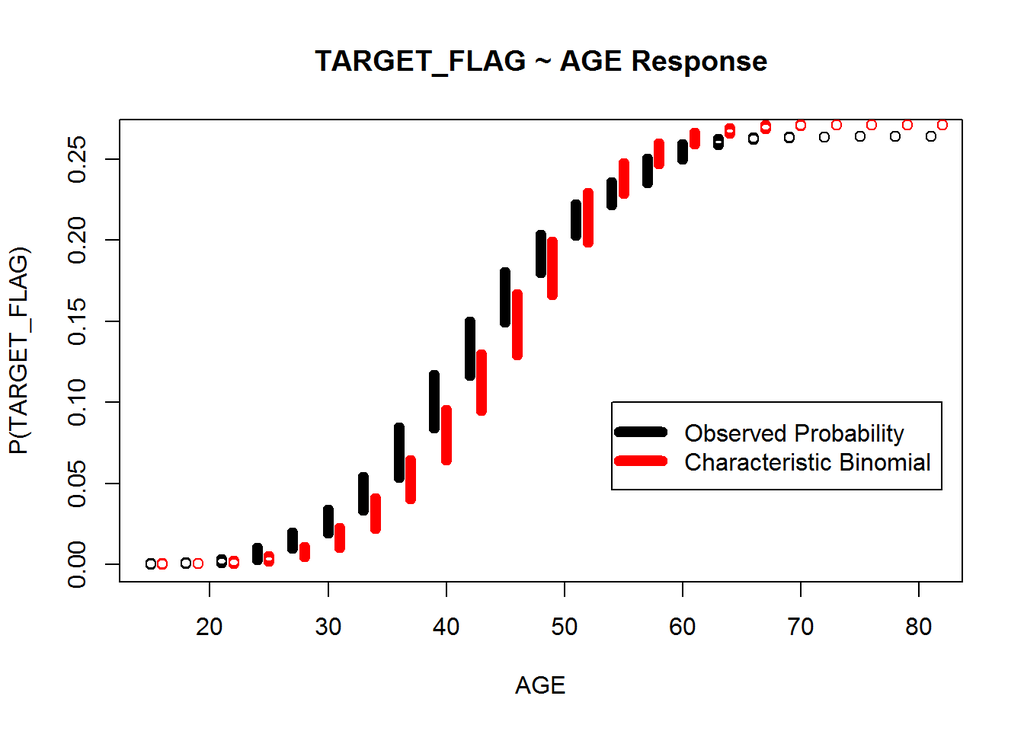

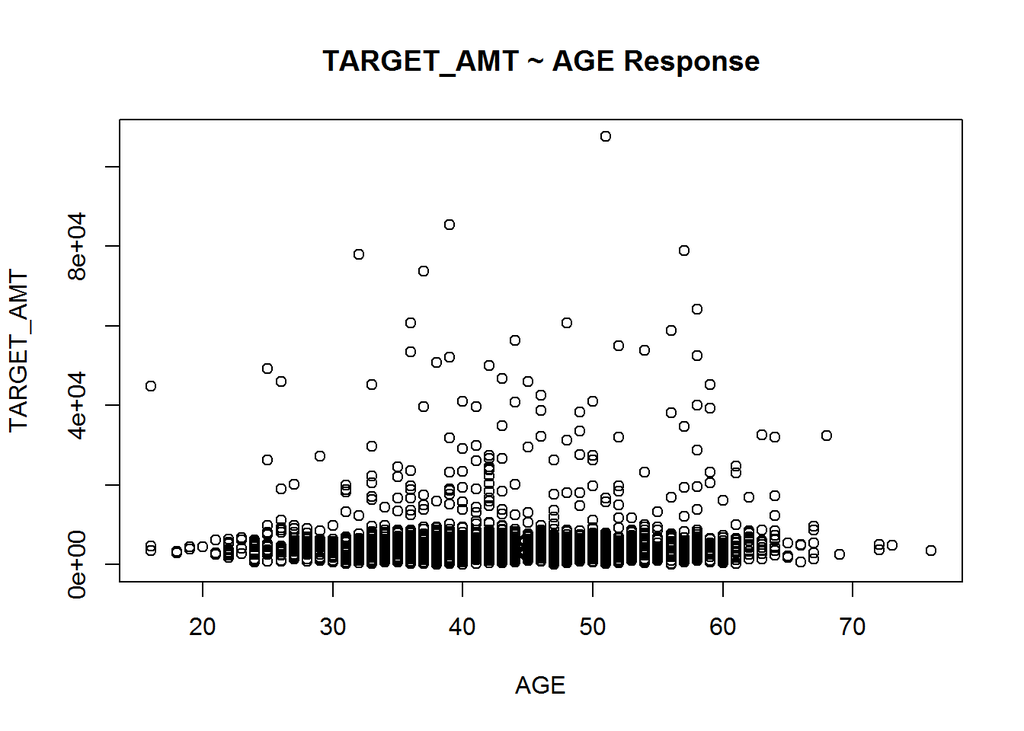

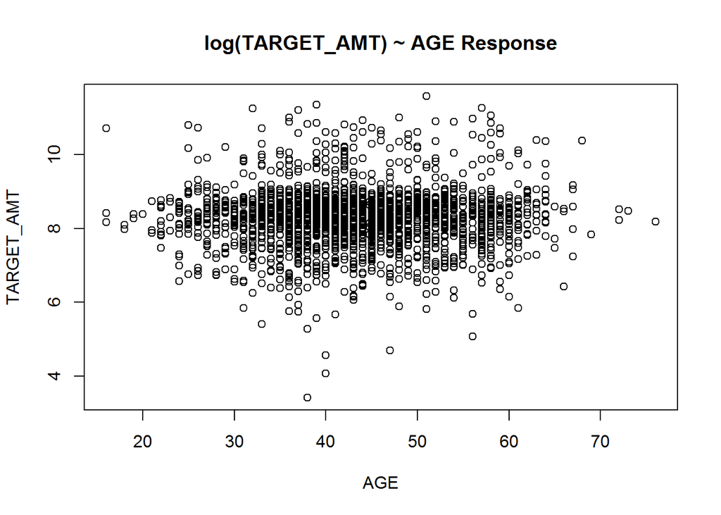

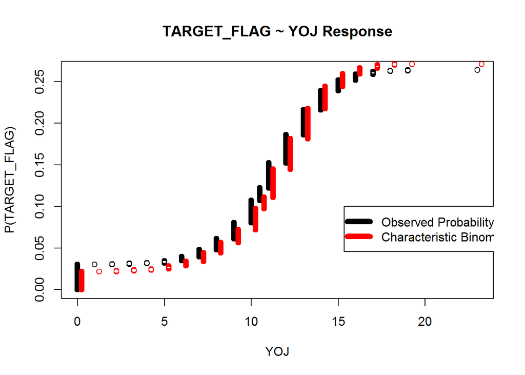

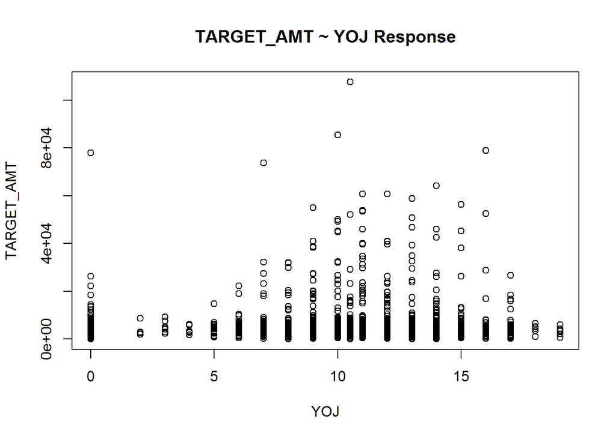

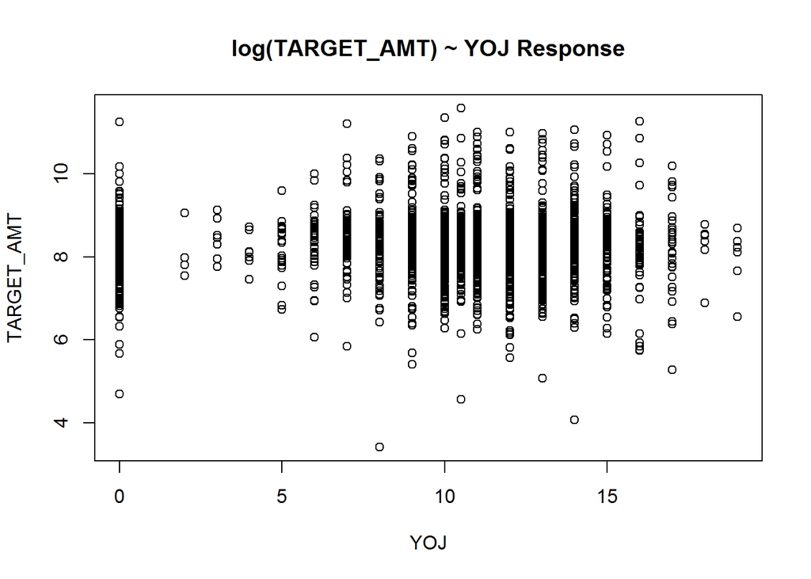

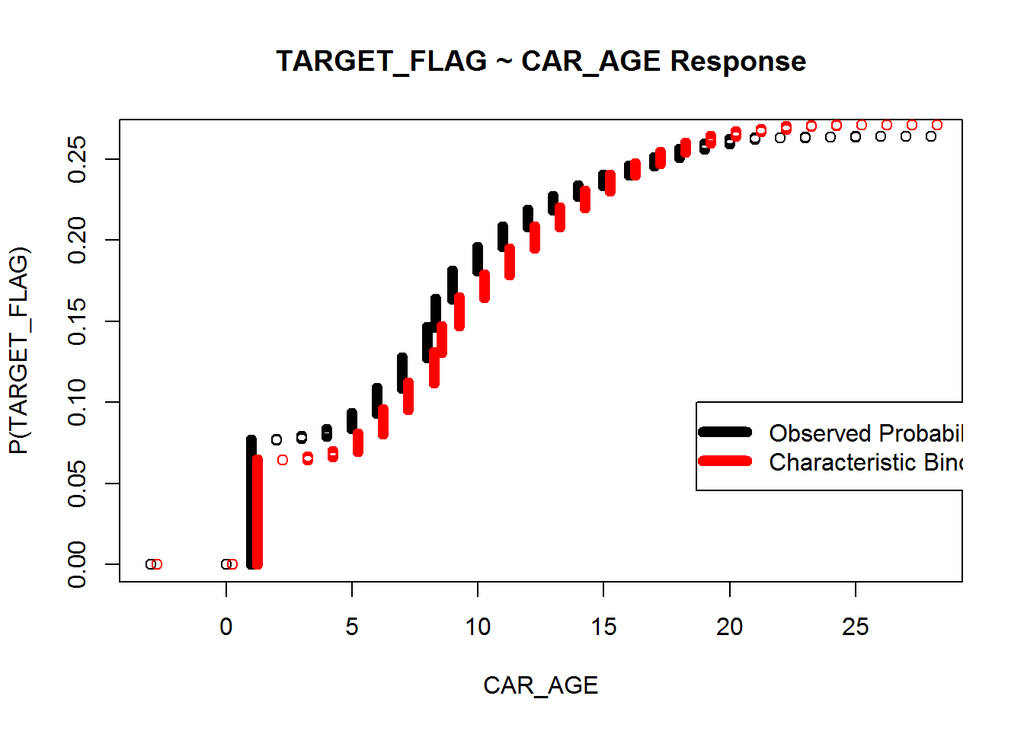

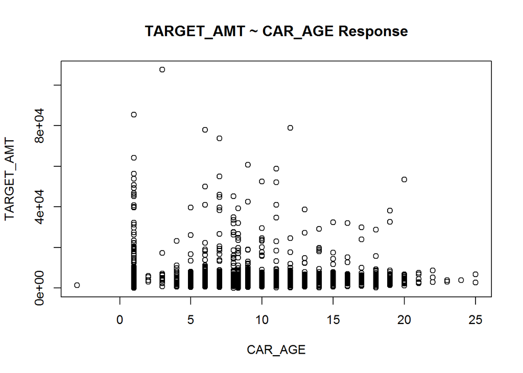

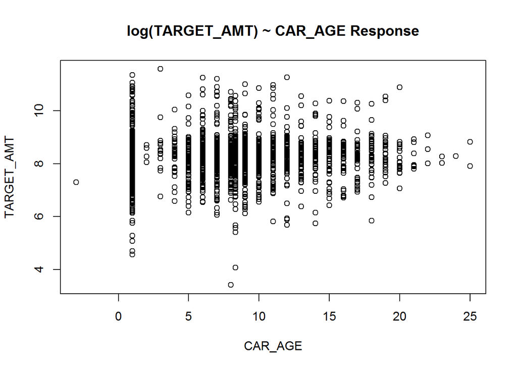

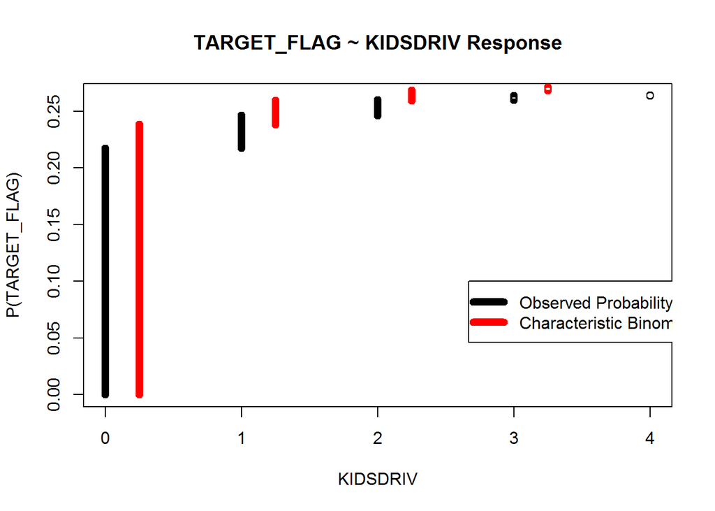

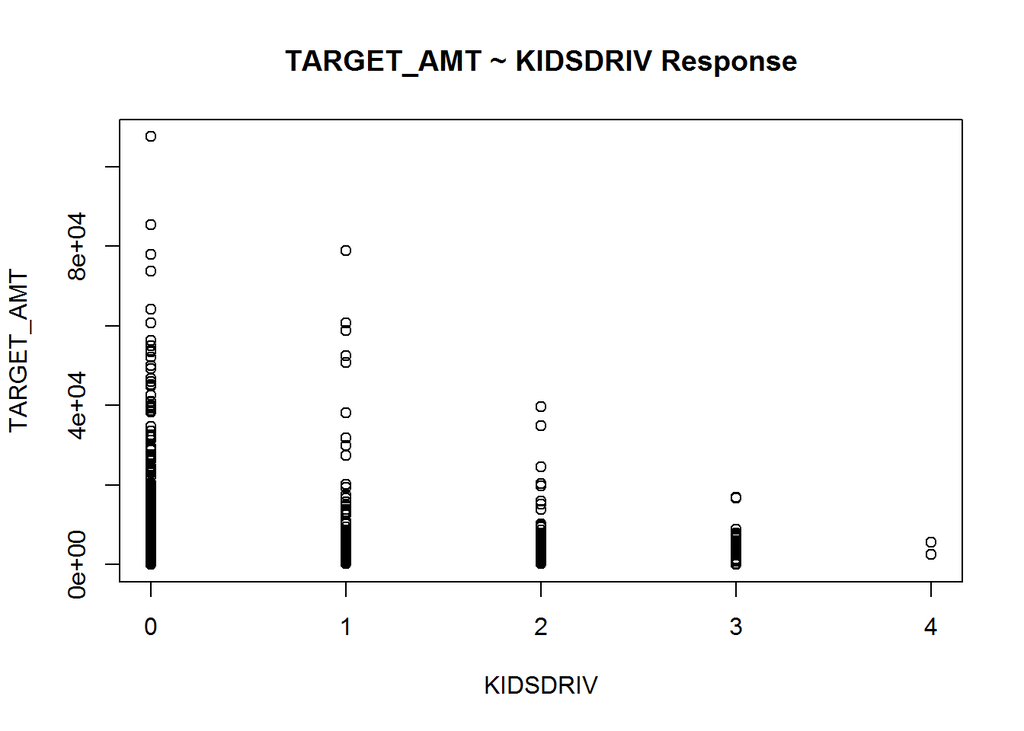

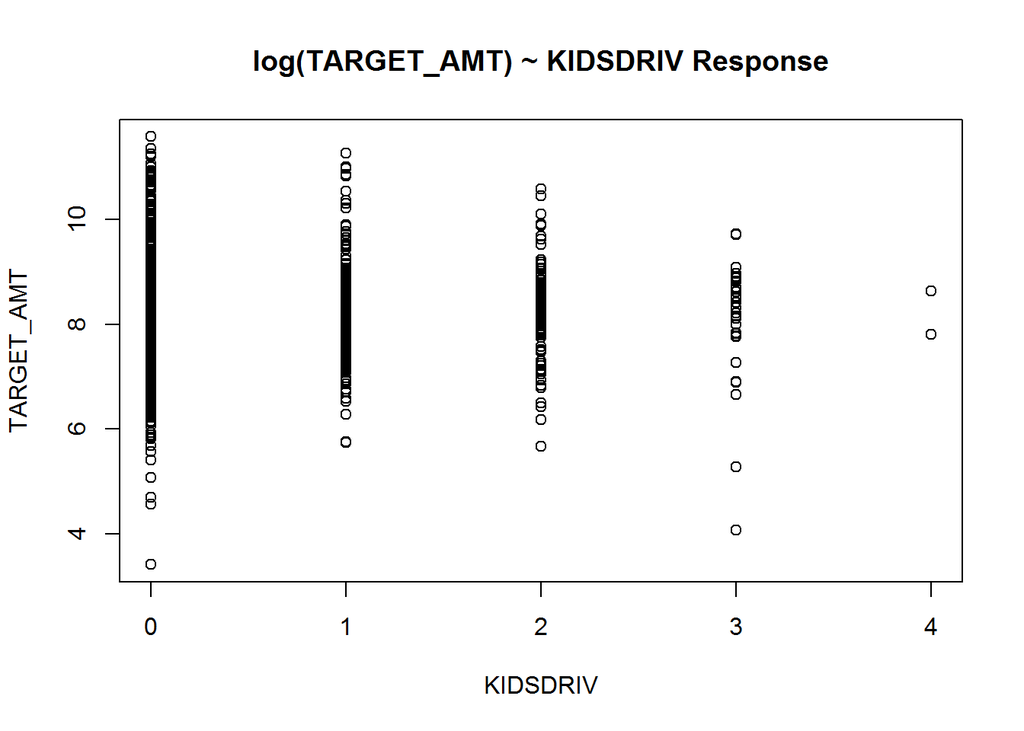

[24 more figures not shown]

```
##       AGE  YOJ CAR_AGE KIDSDRIV HOMEKIDS TRAVTIME  TIF CLM_FREQ MVR_PTS
## [1,] 2153 2153    2153     2153     2153     2153 2153     2153    2153
## [2,] 8161 8161    8161     8161     8161     8161 8161     8161    8161
##      INCOME BLUEBOOK OLDCLAIM
## [1,]   2153     2153     2153
## [2,]   8161     8161     8161
```

```r
y_characteristic <- cumsum(rbinom(nrow(training_trans),1,sum(training_trans$TARGET_FLAG)/length(training_trans$TARGET_FLAG)))/length(training_trans$TARGET_FLAG)
numResponse <- function(col,d){
#  par(mfrow=c(4,1))
    data <- d[order(d[,col]),c(col,target_bin)]
    x <- data[,col]
    decimal_base <- 0.25
    decimal_digits<- log10(sum(range(x)*(c(-1,1))))
    if (decimal_digits >1.8) {
      decimal_base <- 10^floor(decimal_digits-1)
      x<- (x%/%(3*decimal_base)*(3*decimal_base))
    }
    y <- cumsum(data[,target_bin])/length(x)#sum(data[,target_bin])
#    y_inverse <- (sum(data[,target_bin])-cumsum(data[,target_bin]))/sum(data[,target_bin])
    plot(y~x, main=paste0("TARGET_FLAG ~ ",col," Response"),xlab=col, ylab="P(TARGET_FLAG)")
    points(x+decimal_base,y_characteristic,col="red") # adding inverse so it gives a better visual appreciation of what's going on
    legend(max(x)*2/3, 0.1, c("Observed Probability", "Characteristic Binomial"), col = c("black","red"),
           lty=c(1,1),lwd=7,merge = TRUE)

    data <- d[d$TARGET_FLAG==1,]
    data <- data[order(data[,col]),c(col,target_lm)]
    x <- data[,col]
    y <- data[,target_lm]
    plot(y~x, main=paste0("TARGET_AMT ~ ",col," Response"),xlab=col, ylab="TARGET_AMT")

    x <- data[,col]
    y <- log(data[,target_lm])
    plot(y~x, main=paste0("log(TARGET_AMT) ~ ",col," Response"),xlab=col, ylab="TARGET_AMT")
    c(nrow(data),nrow(d))
}


sapply(inputs_num,function(x){numResponse(x,training_trans)})
```

Based on the charts above, we should discretize any variables which don’t give a clear sigmoid function. See how beautiful TARGET_FLAG ~ AGE looks…., if we don’t get a sigmoid off the bat, we’re never going to get a good logistic regression.

The discretization can be tricky. I would discretize in regions where the bars are about the same size (somewhat homogenous). For instance CAR_AGE, I would do CAR_0, CAR_1, CAR_2_4, CAR_5_15, CAR_15_MORE. This is an interesting variable as it appears to be pseudo-sigmoid, with the exception where the car is 1, perhaps a lot of people have accidents past the first year

I’d break HOMEKIDS into: HK_0, HK_1_3, HK_4_MORE

##### **TARGET_NUM**

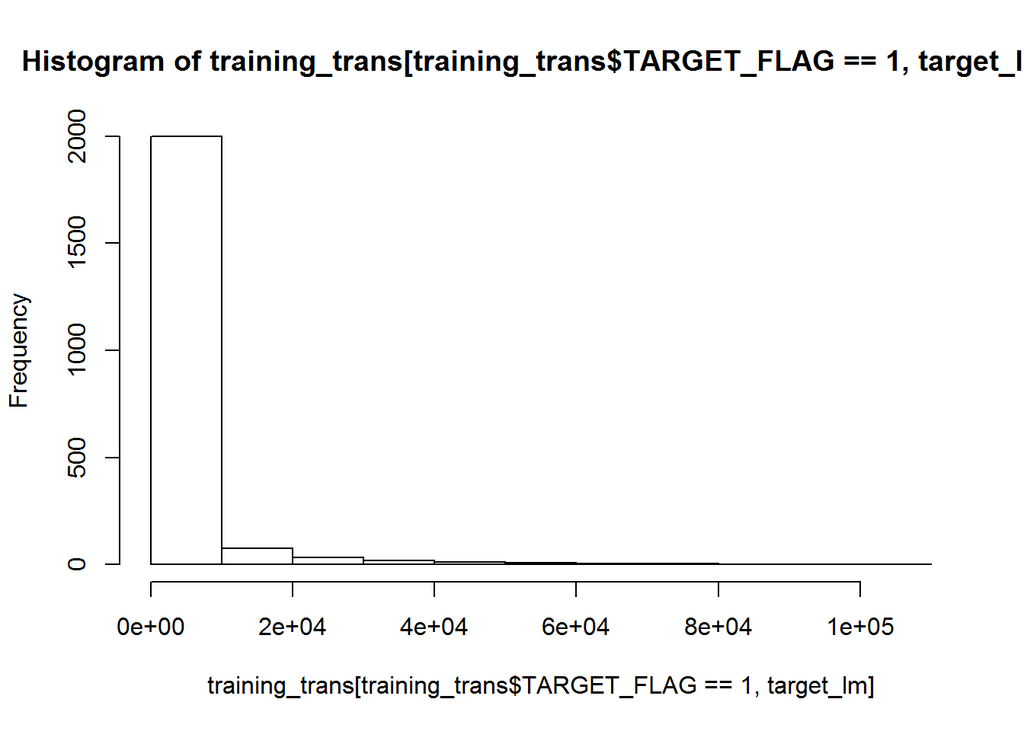

```r
hist(training_trans[training_trans$TARGET_FLAG==1,target_lm])
```

The distribution of values of the response target_lm suggest that we may benefit from a log tranformation on the response.

##### **Transformations Implementation**

Numerical Transformations:

- Cap AGE at 70, negative values not permitted
- Cap YOJ at 20, negative values not permitted
- Cap CAR_AGE at 20, negative values not permitted
- Cap KIDSDRIV at 3, negative values not permitted
- Cap HOMEKIDS at 4, negative values not permitted
- Cap TRAVTIME at 75, negative values not permitted
- Cap TIF at 17, negative values not permitted
- Cap CLM_FREQ at 4, negative values not permitted
- Cap MVR_PTS at 10, negative values not permitted
- Cap INCOME at 175000, negative values not permitted
- Cap BLUEBOOK at 40000, negative values not permitted
- Cap OLDCLAIM at 40000, negative values not permitted

```r
# Cap values

d<- training_trans
capColumns <- function(d){
  outputCols<- colnames(d)


  #* Cap AGE at 70, negative values not permitted
  d[d$AGE <0, 'AGE'] <- 0
  d[d$AGE >=70, 'AGE'] <- 70

  #* Cap YOJ at 20, negative values not permitted
  d[d$YOJ <0, 'YOJ'] <- 0
  d[d$YOJ >=20, 'YOJ'] <- 20

  #* Cap CAR_AGE at 20, negative values not permitted
  d[d$CAR_AGE <0, 'CAR_AGE'] <- 0
  d[d$CAR_AGE >=20, 'CAR_AGE'] <- 20

  #* Cap KIDSDRIV at 3, negative values not permitted
  d[d$KIDSDRIV <0, 'KIDSDRIV'] <- 0
  d[d$KIDSDRIV >=3, 'KIDSDRIV'] <- 3

  #* Cap HOMEKIDS at 4, negative values not permitted
  d[d$HOMEKIDS <0, 'HOMEKIDS'] <- 0
  d[d$HOMEKIDS >=4, 'HOMEKIDS'] <- 4

  #* Cap TRAVTIME at 75, negative values not permitted
  d[d$TRAVTIME <0, 'TRAVTIME'] <- 0
  d[d$TRAVTIME >=75, 'TRAVTIME'] <- 75

  #* Cap TIF at 17, negative values not permitted
  d[d$TIF <0, 'TIF'] <- 0
  d[d$TIF >=17, 'TIF'] <- 17

  #* Cap CLM_FREQ at 4, negative values not permitted
  d[d$CLM_FREQ <0, 'CLM_FREQ'] <- 0
  d[d$CLM_FREQ >=4, 'CLM_FREQ'] <- 4

  #* Cap MVR_PTS at 10, negative values not permitted
  d[d$MVR_PTS <0, 'MVR_PTS'] <- 0
  d[d$MVR_PTS >=10, 'MVR_PTS'] <- 10

  #* Cap INCOME at 175000, negative values not permitted
  d[d$INCOME <0, 'INCOME'] <- 0
  d[d$INCOME >=175000, 'INCOME'] <- 175000

  #* Cap BLUEBOOK at 40000, negative values not permitted
  d[d$BLUEBOOK <0, 'BLUEBOOK'] <- 0
  d[d$BLUEBOOK >=40000, 'BLUEBOOK'] <- 40000

  #* Cap OLDCLAIM at 40000, negative values not permitted
  d[d$OLDCLAIM <0, 'OLDCLAIM'] <- 0
  d[d$OLDCLAIM >=40000, 'OLDCLAIM'] <- 40000

  d

}


training_trans <- capColumns(training_trans)
evaluation_trans <- capColumns(evaluation_trans)
```

#### Final summary

```r
summary <- describe(training_trans[,c(target,inputs)])[,c("n","mean","sd","median","min","max")]
summary$completeness <- summary$n/nrow(training_trans)
summary$cv <- 100*summary$sd/summary$mean

kable(summary)
```

|  | n | mean | sd | median | min | max | completeness | cv |
| --- | --- | --- | --- | --- | --- | --- | --- | --- |
| TARGET_FLAG | 8161 | 2.638157e-01 | 4.407276e-01 | 0.000000 | 0 | 1.0 | 1 | 167.05888 |
| TARGET_AMT | 8161 | 1.504325e+03 | 4.704027e+03 | 0.000000 | 0 | 107586.1 | 1 | 312.70025 |
| PARENT1_BIN | 8161 | 1.319691e-01 | 3.384779e-01 | 0.000000 | 0 | 1.0 | 1 | 256.48267 |
| NON_HOMEOWNER_BIN | 8161 | 3.379488e-01 | 4.730400e-01 | 0.000000 | 0 | 1.0 | 1 | 139.97387 |
| IS_SINGLE_BIN | 8161 | 4.003186e-01 | 4.899929e-01 | 0.000000 | 0 | 1.0 | 1 | 122.40073 |
| IS_MALE_BIN | 8161 | 4.639137e-01 | 4.987266e-01 | 0.000000 | 0 | 1.0 | 1 | 107.50418 |
| ED_HS_BIN | 8161 | 2.855042e-01 | 4.516819e-01 | 0.000000 | 0 | 1.0 | 1 | 158.20499 |
| ED_BACHELORS_BIN | 8161 | 2.747212e-01 | 4.464010e-01 | 0.000000 | 0 | 1.0 | 1 | 162.49237 |
| ED_MASTERS_BIN | 8161 | 2.031614e-01 | 4.023763e-01 | 0.000000 | 0 | 1.0 | 1 | 198.05747 |
| ED_PHD_BIN | 8161 | 8.920480e-02 | 2.850565e-01 | 0.000000 | 0 | 1.0 | 1 | 319.55306 |
| JOB_BLUE_COLLAR_BIN | 8161 | 2.236246e-01 | 4.166988e-01 | 0.000000 | 0 | 1.0 | 1 | 186.33857 |
| JOB_CLERICAL_BIN | 8161 | 1.557407e-01 | 3.626316e-01 | 0.000000 | 0 | 1.0 | 1 | 232.84314 |
| JOB_PROFESSIONAL_BIN | 8161 | 1.368705e-01 | 3.437316e-01 | 0.000000 | 0 | 1.0 | 1 | 251.13642 |
| JOB_MANAGERIAL_BIN | 8161 | 1.210636e-01 | 3.262212e-01 | 0.000000 | 0 | 1.0 | 1 | 269.46264 |
| JOB_LAWYER_BIN | 8161 | 1.023159e-01 | 3.030818e-01 | 0.000000 | 0 | 1.0 | 1 | 296.22167 |
| JOB_STUDENT_BIN | 8161 | 8.724420e-02 | 2.822099e-01 | 0.000000 | 0 | 1.0 | 1 | 323.47119 |
| JOB_DOCTOR_BIN | 8161 | 3.014340e-02 | 1.709922e-01 | 0.000000 | 0 | 1.0 | 1 | 567.26308 |
| JOB_HOME_MAKER_BIN | 8161 | 7.854430e-02 | 2.690427e-01 | 0.000000 | 0 | 1.0 | 1 | 342.53623 |
| IS_COMMERCIAL_BIN | 8161 | 3.711555e-01 | 4.831436e-01 | 0.000000 | 0 | 1.0 | 1 | 130.17282 |
| CAR_PANEL_TRUCK_BIN | 8161 | 8.283300e-02 | 2.756465e-01 | 0.000000 | 0 | 1.0 | 1 | 332.77383 |
| CAR_PICKUP_BIN | 8161 | 1.701997e-01 | 3.758312e-01 | 0.000000 | 0 | 1.0 | 1 | 220.81774 |
| CAR_SPORTS_CAR_BIN | 8161 | 1.111383e-01 | 3.143226e-01 | 0.000000 | 0 | 1.0 | 1 | 282.82106 |
| CAR_VAN_BIN | 8161 | 9.190050e-02 | 2.889031e-01 | 0.000000 | 0 | 1.0 | 1 | 314.36514 |
| CAR_SUV_BIN | 8161 | 2.810930e-01 | 4.495603e-01 | 0.000000 | 0 | 1.0 | 1 | 159.93295 |
| RED_CAR_BIN | 8161 | 2.913859e-01 | 4.544287e-01 | 0.000000 | 0 | 1.0 | 1 | 155.95427 |
| REVOKED_BIN | 8161 | 1.225340e-01 | 3.279216e-01 | 0.000000 | 0 | 1.0 | 1 | 267.61685 |
| IS_URBAN_BIN | 8161 | 7.954907e-01 | 4.033673e-01 | 1.000000 | 0 | 1.0 | 1 | 50.70672 |
| AGE | 8161 | 4.478517e+01 | 8.607250e+00 | 45.000000 | 16 | 70.0 | 1 | 19.21898 |
| YOJ | 8161 | 1.049855e+01 | 3.974963e+00 | 11.000000 | 0 | 20.0 | 1 | 37.86202 |
| CAR_AGE | 8161 | 8.297322e+00 | 5.443049e+00 | 8.328323 | 0 | 20.0 | 1 | 65.60007 |
| KIDSDRIV | 8161 | 1.705673e-01 | 5.083338e-01 | 0.000000 | 0 | 3.0 | 1 | 298.02528 |
| HOMEKIDS | 8161 | 7.195197e-01 | 1.110499e+00 | 0.000000 | 0 | 4.0 | 1 | 154.33896 |
| TRAVTIME | 8161 | 3.338684e+01 | 1.557003e+01 | 33.000000 | 5 | 75.0 | 1 | 46.63522 |
| TIF | 8161 | 5.334273e+00 | 4.090881e+00 | 4.000000 | 1 | 17.0 | 1 | 76.69051 |
| CLM_FREQ | 8161 | 7.963485e-01 | 1.151381e+00 | 0.000000 | 0 | 4.0 | 1 | 144.58254 |
| MVR_PTS | 8161 | 1.693420e+00 | 2.138207e+00 | 1.000000 | 0 | 10.0 | 1 | 126.26560 |
| INCOME | 8161 | 6.627132e+04 | 3.934498e+04 | 66367.000000 | 5 | 175000.0 | 1 | 59.36954 |
| BLUEBOOK | 8161 | 1.566945e+04 | 8.272602e+03 | 14440.000000 | 1500 | 40000.0 | 1 | 52.79447 |
| OLDCLAIM | 8161 | 3.957800e+03 | 8.408736e+03 | 0.000000 | 0 | 40000.0 | 1 | 212.45985 |

```r
#head(training_trans)
#summary(training_trans)
```

### How are the input values distributed?, do we need to do something about them?

Let’s get a view of the normalized values:

# Binary target variable

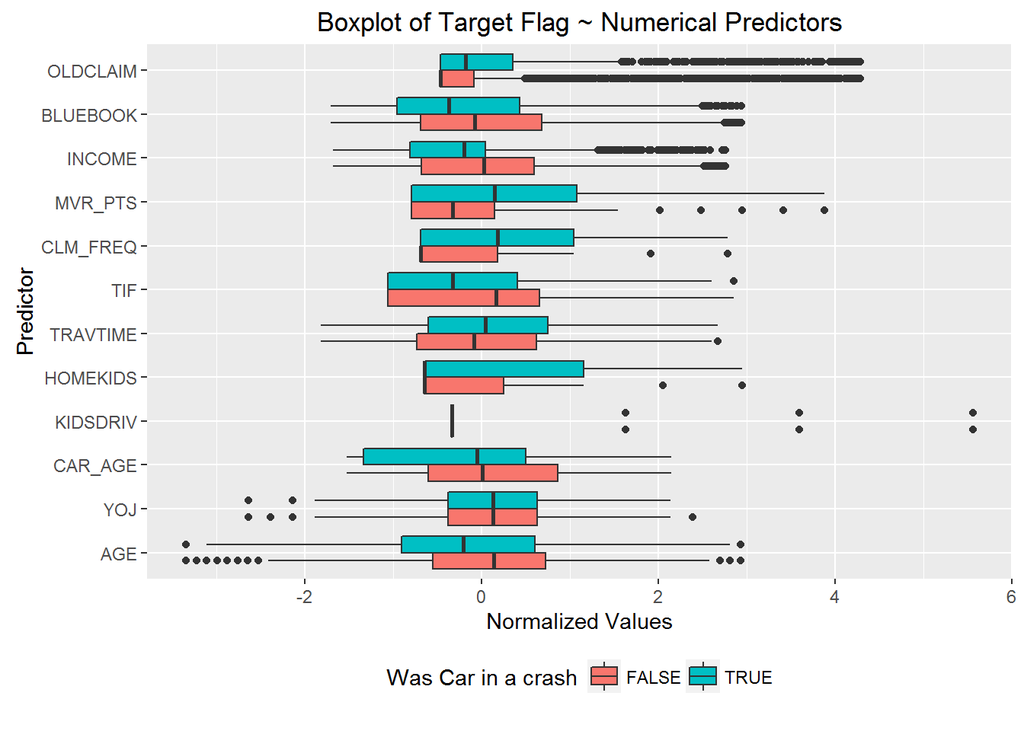

```r
require("reshape2")
require("ggplot2")
detach(package:plyr)
require("dplyr")

# Let's melt the DF so that we can plot it more easily
training_normalized <- cbind(data.frame(scale(training_trans[,inputs_num])),training_trans[,c(inputs_bin,target)])
training_normalized$TARGET_FLAG <- training_normalized$TARGET_FLAG==1

ggplot(melt(training_normalized, measure.vars = inputs_num),
       aes(x=variable,y=value)
       )+
    geom_boxplot(aes(fill = factor(TARGET_FLAG)))+
  guides(fill=guide_legend(title="Was Car in a crash")) +
   theme(legend.position="bottom")+
    coord_flip()+
  labs(title="Boxplot of Target Flag ~ Numerical Predictors", y="Normalized Values", x="Predictor")
```

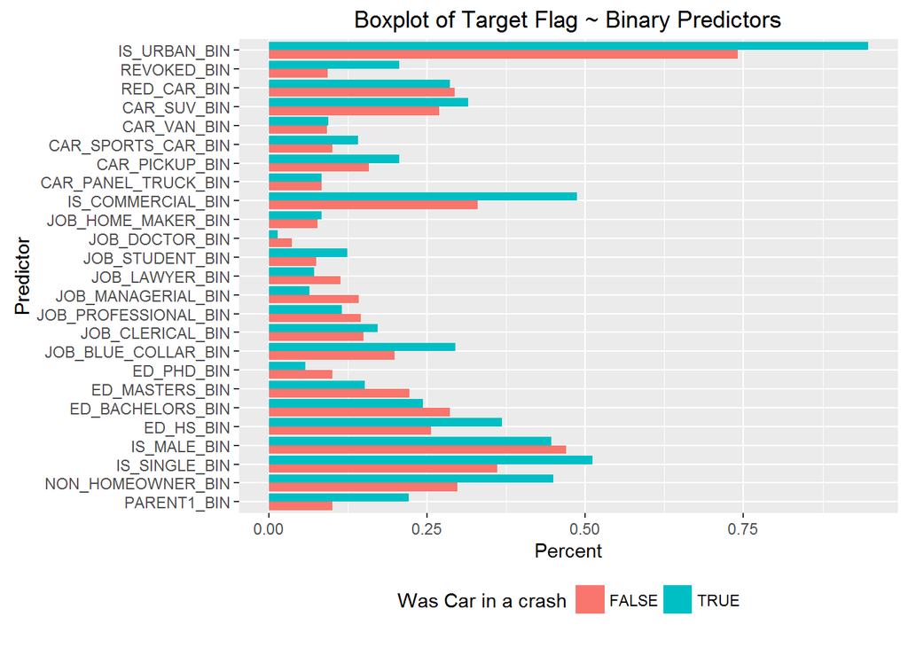

```r
bin_summary <- melt(training_normalized[,c(inputs_bin,target_bin)], measure.vars = inputs_bin) %>%
  group_by(TARGET_FLAG,variable) %>%
  summarise(pct = sum(value)/length(value))

ggplot(bin_summary, aes(variable, pct)) +
  geom_bar(aes(fill = TARGET_FLAG), position = "dodge", stat="identity")+
  guides(fill=guide_legend(title="Was Car in a crash")) +
   theme(legend.position="bottom")+
    coord_flip()+
  labs(title="Boxplot of Target Flag ~ Binary Predictors", y="Percent", x="Predictor")
```

possible correlations

```r
summary_positive <- describe(training_normalized[training_normalized$TARGET_FLAG==1,c(target_bin,inputs)])[,c("mean","n")]
summary_negative <- describe(training_normalized[training_normalized$TARGET_FLAG==0,c(target_bin,inputs)])[,c("mean","n")]
summary_by_target <- merge(summary_positive,summary_negative,by="row.names")
colnames(summary_by_target) <- c("Variable","In car crash - Avg","In car crash - n","NOT In car crash - Avg", "NOT In car crash - n")
summary_by_target$delta <- abs(summary_by_target[,"In car crash - Avg"]-summary_by_target[,"NOT In car crash - Avg"])

kable(summary_by_target[order(-summary_by_target$delta),])
```

|  | Variable | In car crash - Avg | In car crash - n | NOT In car crash - Avg | NOT In car crash - n | delta |
| --- | --- | --- | --- | --- | --- | --- |
| 29 | MVR_PTS | 0.3653840 | 2153 | -0.1309374 | 6008 | 0.4963214 |
| 9 | CLM_FREQ | 0.3624404 | 2153 | -0.1298825 | 6008 | 0.4923229 |
| 31 | OLDCLAIM | 0.2374517 | 2153 | -0.0850921 | 6008 | 0.3225438 |
| 15 | INCOME | -0.1943105 | 2153 | 0.0696322 | 6008 | 0.2639427 |
| 14 | HOMEKIDS | 0.1931797 | 2153 | -0.0692270 | 6008 | 0.2624067 |
| 2 | BLUEBOOK | -0.1762139 | 2153 | 0.0631472 | 6008 | 0.2393611 |
| 28 | KIDSDRIV | 0.1733929 | 2153 | -0.0621363 | 6008 | 0.2355291 |
| 1 | AGE | -0.1727074 | 2153 | 0.0618906 | 6008 | 0.2345980 |
| 3 | CAR_AGE | -0.1617485 | 2153 | 0.0579635 | 6008 | 0.2197120 |
| 19 | IS_URBAN_BIN | 0.9465862 | 2153 | 0.7413449 | 6008 | 0.2052413 |
| 36 | TIF | -0.1372315 | 2153 | 0.0491777 | 6008 | 0.1864092 |
| 16 | IS_COMMERCIAL_BIN | 0.4862982 | 2153 | 0.3298935 | 6008 | 0.1564047 |
| 38 | YOJ | -0.1142741 | 2153 | 0.0409507 | 6008 | 0.1552248 |
| 30 | NON_HOMEOWNER_BIN | 0.4491407 | 2153 | 0.2981025 | 6008 | 0.1510382 |
| 18 | IS_SINGLE_BIN | 0.5109150 | 2153 | 0.3606858 | 6008 | 0.1502292 |
| 32 | PARENT1_BIN | 0.2210869 | 2153 | 0.1000333 | 6008 | 0.1210536 |
| 37 | TRAVTIME | 0.0865733 | 2153 | -0.0310240 | 6008 | 0.1175973 |
| 34 | REVOKED_BIN | 0.2057594 | 2153 | 0.0927097 | 6008 | 0.1130497 |
| 11 | ED_HS_BIN | 0.3683233 | 2153 | 0.2558256 | 6008 | 0.1124977 |
| 20 | JOB_BLUE_COLLAR_BIN | 0.2944728 | 2153 | 0.1982357 | 6008 | 0.0962371 |
| 25 | JOB_MANAGERIAL_BIN | 0.0636321 | 2153 | 0.1416445 | 6008 | 0.0780123 |
| 12 | ED_MASTERS_BIN | 0.1518811 | 2153 | 0.2215379 | 6008 | 0.0696569 |
| 27 | JOB_STUDENT_BIN | 0.1235485 | 2153 | 0.0742344 | 6008 | 0.0493142 |
| 5 | CAR_PICKUP_BIN | 0.2057594 | 2153 | 0.1574567 | 6008 | 0.0483027 |
| 7 | CAR_SUV_BIN | 0.3149094 | 2153 | 0.2689747 | 6008 | 0.0459347 |
| 10 | ED_BACHELORS_BIN | 0.2429169 | 2153 | 0.2861185 | 6008 | 0.0432016 |
| 24 | JOB_LAWYER_BIN | 0.0710636 | 2153 | 0.1135153 | 6008 | 0.0424517 |
| 13 | ED_PHD_BIN | 0.0580585 | 2153 | 0.1003662 | 6008 | 0.0423077 |
| 6 | CAR_SPORTS_CAR_BIN | 0.1411983 | 2153 | 0.1003662 | 6008 | 0.0408321 |
| 26 | JOB_PROFESSIONAL_BIN | 0.1147236 | 2153 | 0.1448069 | 6008 | 0.0300833 |
| 17 | IS_MALE_BIN | 0.4463539 | 2153 | 0.4702064 | 6008 | 0.0238525 |
| 22 | JOB_DOCTOR_BIN | 0.0134696 | 2153 | 0.0361185 | 6008 | 0.0226489 |
| 21 | JOB_CLERICAL_BIN | 0.1723177 | 2153 | 0.1498003 | 6008 | 0.0225174 |
| 33 | RED_CAR_BIN | 0.2861124 | 2153 | 0.2932756 | 6008 | 0.0071632 |
| 23 | JOB_HOME_MAKER_BIN | 0.0836043 | 2153 | 0.0767310 | 6008 | 0.0068732 |
| 8 | CAR_VAN_BIN | 0.0933581 | 2153 | 0.0913782 | 6008 | 0.0019799 |
| 4 | CAR_PANEL_TRUCK_BIN | 0.0826753 | 2153 | 0.0828895 | 6008 | 0.0002141 |
| 35 | TARGET_FLAG* | NaN | 2153 | NaN | 6008 | NaN |

# Numerical target variable - Cost of Car Crash

For our descriptive stats & intuitive understanding, let’s discretize the car crash into Above / Below median cost

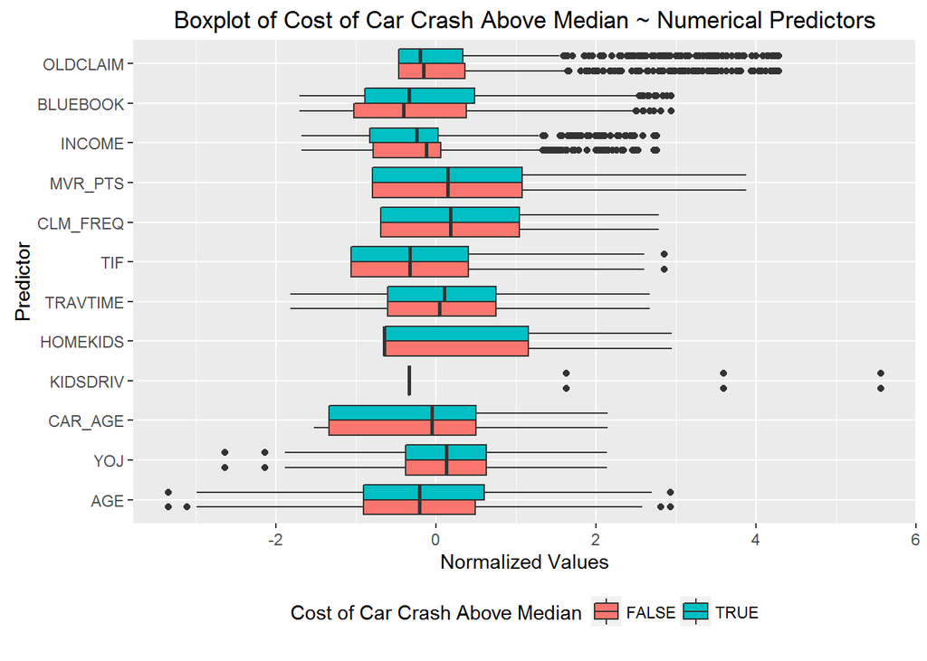

```r
#require("reshape2")
#require("ggplot2")
#detach(package:plyr)
#require("dplyr")

# Let's melt the DF so that we can plot it more easily
training_normalized<-training_normalized[training_normalized$TARGET_FLAG,]

training_normalized$TARGET_FLAG <- training_normalized$TARGET_AMT > median(training_normalized$TARGET_AMT)

ggplot(melt(training_normalized, measure.vars = inputs_num),
       aes(x=variable,y=value)
       )+
    geom_boxplot(aes(fill = factor(TARGET_FLAG)))+
  guides(fill=guide_legend(title="Cost of Car Crash Above Median")) +
   theme(legend.position="bottom")+
    coord_flip()+
  labs(title="Boxplot of Cost of Car Crash Above Median ~ Numerical Predictors", y="Normalized Values", x="Predictor")
```

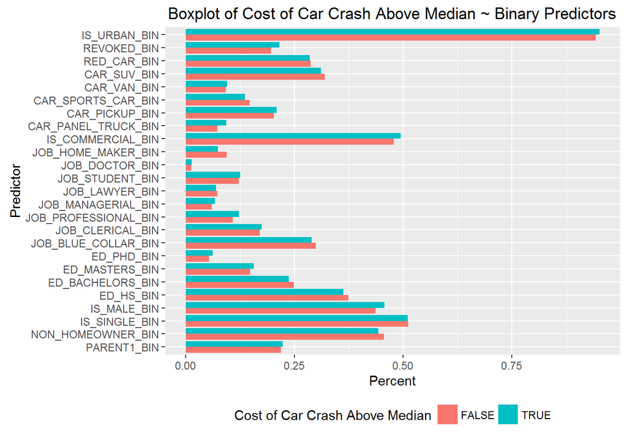

```r
bin_summary <- melt(training_normalized[,c(inputs_bin,target_bin)], measure.vars = inputs_bin) %>%
  group_by(TARGET_FLAG,variable) %>%
  summarise(pct = sum(value)/length(value))

ggplot(bin_summary, aes(variable, pct)) +
  geom_bar(aes(fill = TARGET_FLAG), position = "dodge", stat="identity")+
  guides(fill=guide_legend(title="Cost of Car Crash Above Median")) +
   theme(legend.position="bottom")+
    coord_flip()+
  labs(title="Boxplot of Cost of Car Crash Above Median ~ Binary Predictors", y="Percent", x="Predictor")
```

possible correlations

```r
summary_positive <- describe(training_normalized[training_normalized$TARGET_FLAG==1,c(target_bin,inputs)])[,c("mean","n")]
summary_negative <- describe(training_normalized[training_normalized$TARGET_FLAG==0,c(target_bin,inputs)])[,c("mean","n")]
summary_by_target <- merge(summary_positive,summary_negative,by="row.names")
colnames(summary_by_target) <- c("Variable","Above Median Cost of Crash - Avg","Above Median Cost of Crash - n","Below Median Cost of Crash - Avg", "Below Median Cost of Crash - n")
summary_by_target$delta <- abs(summary_by_target[,"Above Median Cost of Crash - Avg"]-summary_by_target[,"Below Median Cost of Crash - Avg"])

kable(summary_by_target[order(-summary_by_target$delta),])
```

|  | Variable | Above Median Cost of Crash - Avg | Above Median Cost of Crash - n | Below Median Cost of Crash - Avg | Below Median Cost of Crash - n | delta |
| --- | --- | --- | --- | --- | --- | --- |
| 2 | BLUEBOOK | -0.1280176 | 1076 | -0.2243655 | 1077 | 0.0963479 |
| 9 | CLM_FREQ | 0.3165175 | 1076 | 0.4083206 | 1077 | 0.0918031 |
| 38 | YOJ | -0.0763340 | 1076 | -0.1521789 | 1077 | 0.0758448 |
| 29 | MVR_PTS | 0.3946086 | 1076 | 0.3361865 | 1077 | 0.0584221 |
| 14 | HOMEKIDS | 0.2182588 | 1076 | 0.1681238 | 1077 | 0.0501350 |
| 1 | AGE | -0.1484935 | 1076 | -0.1968988 | 1077 | 0.0484052 |
| 36 | TIF | -0.1255575 | 1076 | -0.1488946 | 1077 | 0.0233371 |
| 4 | CAR_PANEL_TRUCK_BIN | 0.0929368 | 1076 | 0.0724234 | 1077 | 0.0205134 |
| 23 | JOB_HOME_MAKER_BIN | 0.0734201 | 1076 | 0.0937790 | 1077 | 0.0203589 |
| 17 | IS_MALE_BIN | 0.4563197 | 1076 | 0.4363974 | 1077 | 0.0199223 |
| 34 | REVOKED_BIN | 0.2156134 | 1076 | 0.1959146 | 1077 | 0.0196988 |
| 3 | CAR_AGE | -0.1712427 | 1076 | -0.1522632 | 1077 | 0.0189796 |
| 16 | IS_COMMERCIAL_BIN | 0.4944238 | 1076 | 0.4781801 | 1077 | 0.0162437 |
| 26 | JOB_PROFESSIONAL_BIN | 0.1217472 | 1076 | 0.1077066 | 1077 | 0.0140406 |
| 15 | INCOME | -0.2010833 | 1076 | -0.1875439 | 1077 | 0.0135394 |
| 30 | NON_HOMEOWNER_BIN | 0.4423792 | 1076 | 0.4558960 | 1077 | 0.0135168 |
| 10 | ED_BACHELORS_BIN | 0.2369888 | 1076 | 0.2488394 | 1077 | 0.0118505 |
| 11 | ED_HS_BIN | 0.3624535 | 1076 | 0.3741876 | 1077 | 0.0117340 |
| 6 | CAR_SPORTS_CAR_BIN | 0.1356877 | 1076 | 0.1467038 | 1077 | 0.0110161 |
| 20 | JOB_BLUE_COLLAR_BIN | 0.2899628 | 1076 | 0.2989786 | 1077 | 0.0090158 |
| 7 | CAR_SUV_BIN | 0.3104089 | 1076 | 0.3194058 | 1077 | 0.0089968 |
| 12 | ED_MASTERS_BIN | 0.1561338 | 1076 | 0.1476323 | 1077 | 0.0085015 |
| 25 | JOB_MANAGERIAL_BIN | 0.0678439 | 1076 | 0.0594243 | 1077 | 0.0084195 |
| 13 | ED_PHD_BIN | 0.0622677 | 1076 | 0.0538533 | 1077 | 0.0084144 |
| 19 | IS_URBAN_BIN | 0.9507435 | 1076 | 0.9424327 | 1077 | 0.0083108 |
| 37 | TRAVTIME | 0.0900572 | 1076 | 0.0830926 | 1077 | 0.0069646 |
| 5 | CAR_PICKUP_BIN | 0.2091078 | 1076 | 0.2024141 | 1077 | 0.0066937 |
| 31 | OLDCLAIM | 0.2347958 | 1076 | 0.2401051 | 1077 | 0.0053093 |
| 28 | KIDSDRIV | 0.1708870 | 1076 | 0.1758964 | 1077 | 0.0050095 |
| 21 | JOB_CLERICAL_BIN | 0.1747212 | 1076 | 0.1699164 | 1077 | 0.0048048 |
| 32 | PARENT1_BIN | 0.2230483 | 1076 | 0.2191272 | 1077 | 0.0039211 |
| 27 | JOB_STUDENT_BIN | 0.1254647 | 1076 | 0.1216342 | 1077 | 0.0038305 |
| 8 | CAR_VAN_BIN | 0.0947955 | 1076 | 0.0919220 | 1077 | 0.0028735 |
| 24 | JOB_LAWYER_BIN | 0.0697026 | 1076 | 0.0724234 | 1077 | 0.0027208 |
| 33 | RED_CAR_BIN | 0.2853160 | 1076 | 0.2869081 | 1077 | 0.0015921 |
| 18 | IS_SINGLE_BIN | 0.5102230 | 1076 | 0.5116063 | 1077 | 0.0013833 |
| 22 | JOB_DOCTOR_BIN | 0.0139405 | 1076 | 0.0129991 | 1077 | 0.0009414 |
| 35 | TARGET_FLAG* | NaN | 1076 | NaN | 1077 | NaN |